# Growth Curve Analysis: Exercise Solutions

# Exercise 3 Solution

**`Az`**: Use natural (not orthogonal) polynomials to analyze decline in performance of 30 individuals with probable Alzheimer’s disease on three different kinds of tasks.

```r
summary(Az)
```

```
##     Subject         Time          Task      Performance
##  1      : 30   Min.   : 1.0   cADL  :300   Min.   : 2.0
##  2      : 30   1st Qu.: 3.0   sADL  :300   1st Qu.:40.0
##  3      : 30   Median : 5.5   Memory:300   Median :52.0
##  4      : 30   Mean   : 5.5                Mean   :49.3
##  5      : 30   3rd Qu.: 8.0                3rd Qu.:61.0
##  6      : 30   Max.   :10.0                Max.   :85.0
##  (Other):720
```

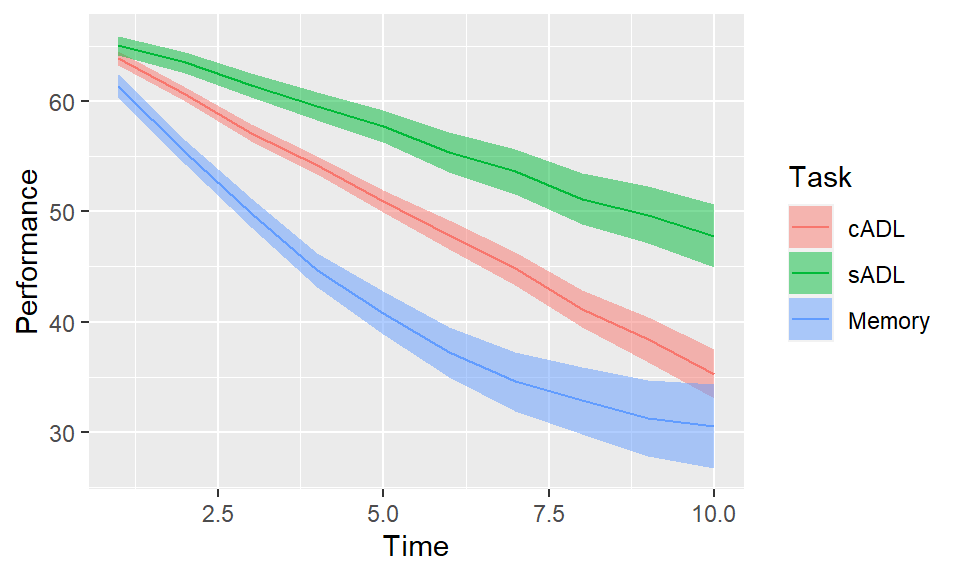

```r
ggplot(Az, aes(Time, Performance, color=Task, fill=Task)) +
  stat_summary(fun.data=mean_se, geom="ribbon", color=NA, alpha=0.5) +
  stat_summary(fun=mean, geom="line")
```

# Exercise 3 Solution: Fit the models

```r
# prep for analysis
Az <- code_poly(Az, predictor="Time", poly.order=2, orthogonal=F, draw.poly = F)
# fit the full model
# m.base <- lmer(Performance ~ (poly1 + poly2) +
#                  (poly1 + poly2 | Subject) + (poly1 + poly2 | Subject:Task),
#                data=Az, REML=F)
# m.0 <- lmer(Performance ~ (poly1 + poly2) + Task +
#               (poly1 + poly2 | Subject) + (poly1 + poly2 | Subject:Task),
#             data=Az, REML=F)
# m.1 <- lmer(Performance ~ poly1*Task + poly2 +
#               (poly1 + poly2 | Subject) + (poly1 + poly2 | Subject:Task),
#             data=Az, REML=F)
m.Az.full <- lmer(Performance ~ (poly1 + poly2)*Task +
                  (poly1 + poly2 | Subject) + (poly1 + poly2 | Subject:Task),
                data=Az, REML=F)
```

```
## boundary (singular) fit: see ?isSingular
```

```r
# anova(m.base, m.0, m.1, m.Az.full)
```

# Exercise 3 Solution: Get p-values

```r
get_pvalues(m.Az.full)
```

```
##                  Estimate Std..Error  t.value  p.normal p.normal.star
## (Intercept)      67.16167    0.92668  72.4754 0.000e+00           ***
## poly1            -3.28780    0.34106  -9.6399 0.000e+00           ***
## poly2             0.00947    0.01243   0.7615 4.463e-01
## TasksADL          0.09500    0.81186   0.1170 9.068e-01
## TaskMemory        1.24000    0.81186   1.5274 1.267e-01
## poly1:TasksADL    1.36220    0.26751   5.0921 3.540e-07           ***
## poly1:TaskMemory -3.97707    0.26751 -14.8670 0.000e+00           ***
## poly2:TasksADL   -0.01326    0.01748  -0.7585 4.481e-01
## poly2:TaskMemory  0.33889    0.01748  19.3892 0.000e+00           ***
```

- Intercepts are not different: performance in all tasks starts out the same (thanks, natural polynomials)
- Linear slopes are different: compared to complex ADL tasks, decline in simple ADL tasks is slower and decline in Memory is faster.
- Quadratic term is different for Memory: decline in cADL and sADL tasks is approximately linear, decline in Memory has more curvature (reaching floor?)

# Exercise 3 Solution: Plot model fit

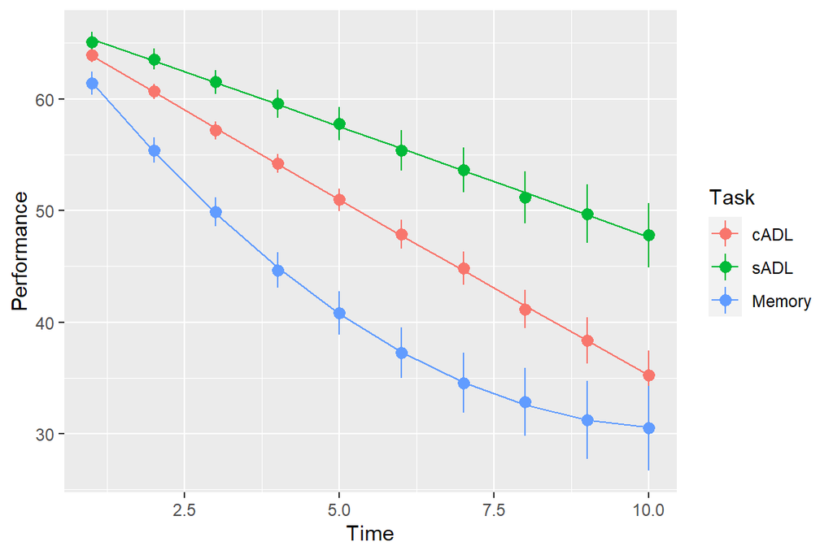

```r
ggplot(Az, aes(Time, Performance, color=Task)) +
  stat_summary(fun.data=mean_se, geom="pointrange") +
  stat_summary(fun=mean, geom="line", aes(y=fitted(m.Az.full)))
```

# Exercise 4 Solution

Re-analyze the word learning data using logistic GCA.

```r
# calculate number correct and incorrect
WordLearnEx <- mutate(WordLearnEx,
                      Correct = round(Accuracy*6),
                      Error = 6-Correct)
# prep for GCA
WordLearnEx <- code_poly(WordLearnEx, predictor="Block", poly.order=2, draw.poly=F)
# fit logistic model
wl.logit <- glmer(cbind(Correct, Error) ~ (poly1+poly2)*TP +
                    (poly1+poly2 | Subject),
                  data=WordLearnEx, family=binomial)
```

```
## boundary (singular) fit: see ?isSingular
```

```r
coef(summary(wl.logit))
```

```
##              Estimate Std. Error z value  Pr(>|z|)
## (Intercept)   1.58261     0.1982  7.9861 1.392e-15
## poly1         2.21221     0.3234  6.8403 7.904e-12
## poly2        -0.08209     0.2318 -0.3542 7.232e-01
## TPHigh        0.56565     0.2842  1.9904 4.654e-02
## poly1:TPHigh  0.34726     0.4474  0.7762 4.376e-01
## poly2:TPHigh -0.98955     0.3254 -3.0407 2.360e-03
```

# Exercise 4 Solution: Compare with linear GCA

```r
wl.lin <- lmer(Accuracy ~ (poly1+poly2)*TP +
                 (poly1+poly2 | Subject),
               data=WordLearnEx, REML=F)
```

```
## boundary (singular) fit: see ?isSingular
```

```r
summary(wl.lin)
```

```
## Linear mixed model fit by maximum likelihood  ['lmerMod']
## Formula: Accuracy ~ (poly1 + poly2) * TP + (poly1 + poly2 | Subject)
##    Data: WordLearnEx
##
##      AIC      BIC   logLik deviance df.resid
##   -332.6   -276.4    179.3   -358.6      547
##
## Scaled residuals:
##    Min     1Q Median     3Q    Max
## -3.618 -0.536  0.126  0.567  2.616
##
## Random effects:
##  Groups   Name        Variance Std.Dev. Corr
##  Subject  (Intercept) 0.01076  0.1037
##           poly1       0.01542  0.1242   -0.33
##           poly2       0.00628  0.0792   -0.28 -0.82
##  Residual             0.02456  0.1567
## Number of obs: 560, groups:  Subject, 56
##
## Fixed effects:
##              Estimate Std. Error t value
## (Intercept)   0.77853    0.02173   35.83
## poly1         0.28632    0.03779    7.58
## poly2        -0.05085    0.03319   -1.53
## TPHigh        0.05296    0.03073    1.72
## poly1:TPHigh  0.00108    0.05344    0.02
## poly2:TPHigh -0.11645    0.04693   -2.48
##
## Correlation of Fixed Effects:
##             (Intr) poly1  poly2  TPHigh p1:TPH
## poly1       -0.183
## poly2       -0.114 -0.229
## TPHigh      -0.707  0.129  0.081
## poly1:TPHgh  0.129 -0.707  0.162 -0.183
## poly2:TPHgh  0.081  0.162 -0.707 -0.114 -0.229
## convergence code: 0
## boundary (singular) fit: see ?isSingular
```

- TP effects are stronger in the logistic model. In particular, the TP effect on the intercept is statistically significant in the logistic model, but only marginal in the linear model.
- Logistic model parameter estimates are on logit scale instead of proportions scale

# Exercise 4 Solution: Plot model fits

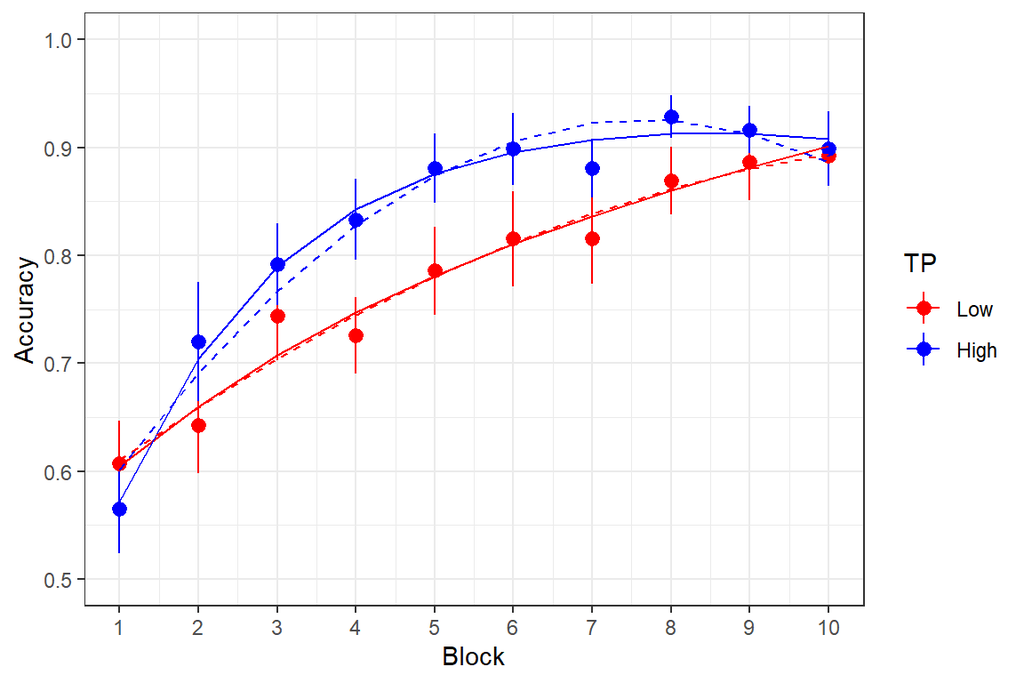

```r
ggplot(WordLearnEx, aes(Block, Accuracy, color=TP)) +
  stat_summary(fun.data = mean_se, geom="pointrange") +
  stat_summary(aes(y=fitted(wl.logit)), fun = mean, geom="line") +
  stat_summary(aes(y=fitted(wl.lin)), fun = mean, geom="line", linetype="dashed") +
  theme_bw() + expand_limits(y=c(0.5, 1.0)) + scale_x_continuous(breaks=1:10) +
  scale_color_manual(values=c("red", "blue")) + labs(y="Accuracy")
```

# Exercise 5 Solution

Cohort and rhyme competition in three groups of participants.

Make a multi-panel plot showing each kind of competition for each group

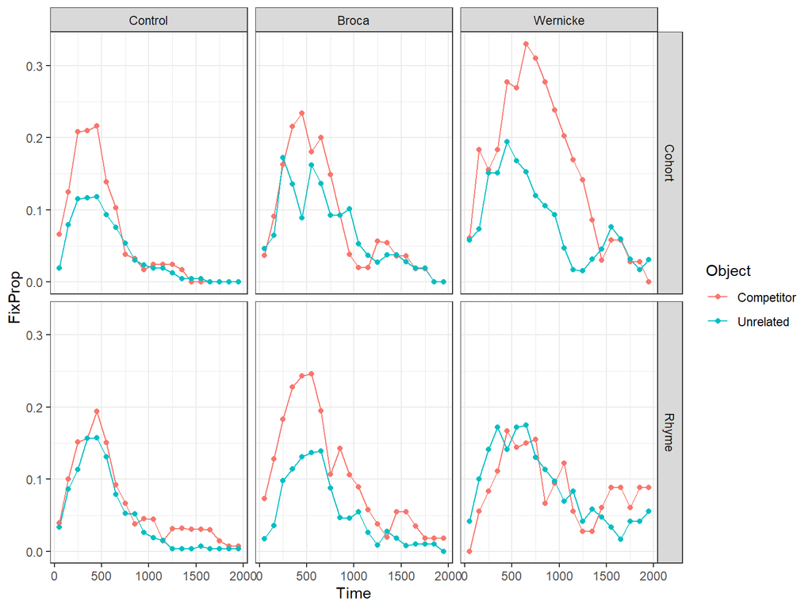

```r
ggplot(CohortRhyme, aes(Time, FixProp, color=Object)) +
  facet_grid(Type ~ Group) + stat_summary(fun=mean, geom="line") +
  stat_summary(fun=mean, geom="point") + theme_bw()
```

# Exercise 5 Solution: Group comparisons

Use fourth-order orthogonal polynomials to analyze (separately) the cohort and rhyme competition effects. Do the diagnosis groups differ in competition effect sizes?

```r
# prep for GCA
CohortRhyme.gca <- code_poly(df=CohortRhyme, predictor="timeBin", poly.order=4, draw.poly = FALSE)
# group effects on cohort competition
cohort.base <- lmer(FixProp ~ (poly1+poly2+poly3+poly4)*Object +
                      (1+poly1+poly2+poly3+poly4 | subjID) +
                      (1+poly1+poly2 | subjID:Object),
                    data=subset(CohortRhyme.gca, Type == "Cohort"), REML=F)
```

```
## boundary (singular) fit: see ?isSingular
```

```r
cohort.group <- lmer(FixProp ~ (poly1+poly2+poly3+poly4)*Object*Group +
                       (1+poly1+poly2+poly3+poly4 | subjID) +
                       (1+poly1+poly2 | subjID:Object),
                     data=subset(CohortRhyme.gca, Type == "Cohort"), REML=F)
```

```
## boundary (singular) fit: see ?isSingular
```

```r
gt(anova(cohort.base, cohort.group), rownames_to_stub = TRUE) %>%
  tab_header(title = "Cohort model comparisons")
```

Cohort model comparisons

|  | npar | AIC | BIC | logLik | deviance | Chisq | Df | Pr(>Chisq) |
| --- | --- | --- | --- | --- | --- | --- | --- | --- |
| cohort.base | 32 | -2278 | -2128 | 1171 | -2342 | NA | NA | NA |
| cohort.group | 52 | -2304 | -2060 | 1204 | -2408 | 66 | 20 | 8.089e-07 |

```r
#group effects on rhyme competition
rhyme.base <- lmer(FixProp ~ (poly1+poly2+poly3+poly4)*Object +
                     (1+poly1+poly2+poly3+poly4 | subjID) +
                     (1+poly1+poly2 | subjID:Object),
                   data=subset(CohortRhyme.gca, Type == "Rhyme"), REML=F)
```

```
## boundary (singular) fit: see ?isSingular
```

```r
rhyme.group <- lmer(FixProp ~ (poly1+poly2+poly3+poly4)*Object*Group +
                      (1+poly1+poly2+poly3+poly4 | subjID) +
                      (1+poly1+poly2 | subjID:Object),
                    data=subset(CohortRhyme.gca, Type == "Rhyme"), REML=F)
```

```
## boundary (singular) fit: see ?isSingular
```

```r
gt(anova(rhyme.base, rhyme.group), rownames_to_stub = TRUE) %>%
  tab_header(title = "Rhyme model comparisons")
```

Rhyme model comparisons

|  | npar | AIC | BIC | logLik | deviance | Chisq | Df | Pr(>Chisq) |
| --- | --- | --- | --- | --- | --- | --- | --- | --- |
| rhyme.base | 32 | -2270 | -2120 | 1167 | -2334 | NA | NA | NA |
| rhyme.group | 52 | -2263 | -2020 | 1184 | -2367 | 33.65 | 20 | 0.02862 |

# Exercise 5 Solution: Individual competition effect sizes

Use random effects to compute individual competition effect sizes (note: you’ll need to use a model without any group fixed effects to get random effects relative to the overall sample rather than the diagnosis sub-group).

```r
# get cohort effect sizes
ES.coh <- get_ranef(cohort.base, 'subjID:Object') %>%
  group_by(subjID) %>%
  summarize(subjID = unique(subjID),
            Cohort.Intercept = Intercept[Object=="Competitor"] - Intercept[Object=="Unrelated"],
            Cohort.Linear = poly1[Object=="Competitor"] - poly1[Object=="Unrelated"],
            Cohort.Quadratic = poly2[Object=="Competitor"] - poly2[Object=="Unrelated"])
#head(ES.coh)
# get rhyme effect sizes
ES.rhy <- get_ranef(rhyme.base, 'subjID:Object') %>%
  group_by(subjID) %>%
  summarize(subjID = unique(subjID),
            Rhyme.Intercept = Intercept[Object=="Competitor"] - Intercept[Object=="Unrelated"],
            Rhyme.Linear = poly1[Object=="Competitor"] - poly1[Object=="Unrelated"],
            Rhyme.Quadratic = poly2[Object=="Competitor"] - poly2[Object=="Unrelated"])
#head(ES.rhy)
# combine cohort and rhyme individual effect sizes
ES <- merge(ES.coh, ES.rhy, by="subjID")
# get grouping info from original data frame
group <- unique(subset(CohortRhyme, select=c(subjID, Group)))
ES <- merge(ES, group, by="subjID")
summary(ES)
```

```
##      subjID    Cohort.Intercept   Cohort.Linear      Cohort.Quadratic
##  Min.   :101   Min.   :-0.04923   Min.   :-0.15156   Min.   :-0.3099
##  1st Qu.:106   1st Qu.:-0.01712   1st Qu.:-0.05346   1st Qu.:-0.0832
##  Median :110   Median :-0.00985   Median :-0.00336   Median : 0.0263
##  Mean   :110   Mean   : 0.00000   Mean   : 0.00000   Mean   : 0.0000
##  3rd Qu.:115   3rd Qu.: 0.02199   3rd Qu.: 0.06445   3rd Qu.: 0.0896
##  Max.   :120   Max.   : 0.06869   Max.   : 0.13670   Max.   : 0.1444
##  Rhyme.Intercept     Rhyme.Linear     Rhyme.Quadratic        Group
##  Min.   :-0.04664   Min.   :-0.2445   Min.   :-0.1237   Control :12
##  1st Qu.:-0.01774   1st Qu.:-0.1184   1st Qu.:-0.0522   Broca   : 5
##  Median :-0.00936   Median : 0.0543   Median : 0.0168   Wernicke: 3
##  Mean   : 0.00000   Mean   : 0.0000   Mean   : 0.0000
##  3rd Qu.: 0.01676   3rd Qu.: 0.1060   3rd Qu.: 0.0541
##  Max.   : 0.06739   Max.   : 0.1273   Max.   : 0.1193
```

# Correlations among individual competition effect sizes

Test correlations between cohort and rhyme competition effects for patients and controls.

```r
# compute correlations, tidy results, and bind into rows of a data frame
es_corrs <- rbind(
  #effect size correlations: Intercept
  tidy(cor.test(ES$Cohort.Intercept, ES$Rhyme.Intercept)),
  tidy(cor.test(ES$Cohort.Intercept[ES$Group != "Control"], ES$Rhyme.Intercept[ES$Group != "Control"])),
  tidy(cor.test(ES$Cohort.Intercept[ES$Group == "Control"], ES$Rhyme.Intercept[ES$Group == "Control"])),
  #effect size correlations: Linear
  tidy(cor.test(ES$Cohort.Linear, ES$Rhyme.Linear)),
  tidy(cor.test(ES$Cohort.Linear[ES$Group != "Control"], ES$Rhyme.Linear[ES$Group != "Control"])),
  tidy(cor.test(ES$Cohort.Linear[ES$Group == "Control"], ES$Rhyme.Linear[ES$Group == "Control"])),
  #effect size correlations: Quadratic
  tidy(cor.test(ES$Cohort.Quadratic, ES$Rhyme.Quadratic)),
  tidy(cor.test(ES$Cohort.Quadratic[ES$Group != "Control"], ES$Rhyme.Quadratic[ES$Group != "Control"])),
  tidy(cor.test(ES$Cohort.Quadratic[ES$Group == "Control"], ES$Rhyme.Quadratic[ES$Group == "Control"])))
# combine with labels
tab_df <- cbind(Term = rep(c("Intercept", "Linear", "Quadratic"), each=3),
                Group = rep(c("Overall", "Aphasia", "Control"), 3),
                es_corrs)
#print correlations
gt(tab_df[, 1:8]) %>%
  fmt_number(columns = c(3:5, 7:8), decimals = 3) %>%
  tab_header(title = "Competition effect size correlations")
```

Competition effect size correlations

| Term | Group | estimate | statistic | p.value | parameter | conf.low | conf.high |
| --- | --- | --- | --- | --- | --- | --- | --- |
| Intercept | Overall | −0.383 | −1.757 | 0.096 | 18 | −0.706 | 0.072 |
| Intercept | Aphasia | −0.861 | −4.138 | 0.006 | 6 | −0.974 | −0.396 |
| Intercept | Control | 0.338 | 1.135 | 0.283 | 10 | −0.293 | 0.764 |
| Linear | Overall | −0.022 | −0.094 | 0.926 | 18 | −0.460 | 0.425 |
| Linear | Aphasia | −0.438 | −1.195 | 0.277 | 6 | −0.873 | 0.385 |
| Linear | Control | 0.473 | 1.696 | 0.121 | 10 | −0.139 | 0.823 |
| Quadratic | Overall | −0.022 | −0.092 | 0.928 | 18 | −0.460 | 0.425 |
| Quadratic | Aphasia | 0.056 | 0.137 | 0.895 | 6 | −0.675 | 0.732 |
| Quadratic | Control | −0.170 | −0.545 | 0.598 | 10 | −0.678 | 0.448 |

# Scatterplot

Make a multi-panel scatterplot showing these correlations.

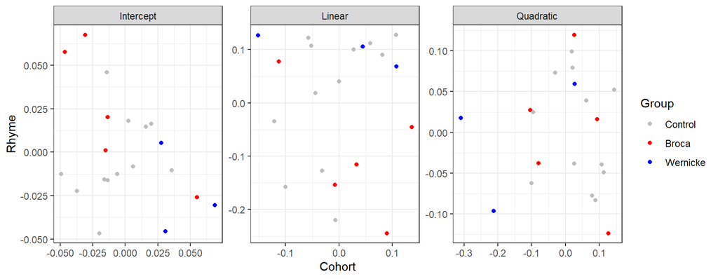

```r
ES.p <- ES %>%
  pivot_longer(cols=2:7, # pivot the effect size estimates into long form
               names_to="key", values_to="EffectSize") %>%
  separate(key, c("Type", "Term"), sep = "\\.") %>% # separate column labels for plotting
  pivot_wider(names_from = Type, values_from = EffectSize) # pivot Cohort and Rhyme effects into separate columns

ggplot(ES.p, aes(Cohort, Rhyme, color=Group)) +
  facet_wrap(~ Term, scales="free") + geom_point() +
  scale_color_manual(values=c("grey", "red", "blue")) +
  theme_bw()
```